# pd5

Praca domowa 5

Autor: Jakub Białek

29.04.2020

Informacje ogólne:

- zmienna objaśniana transformowana log3
- permutation importance wykonane z pomocą sklearn.inspection.permutation_importance, defaultowe parametry, liczone na zbiorze testowym

#### For the selected data set, train at least one tree-based ensemble model (random forest, gbm, catboost or any other boosting)

#### Calculate permutational variable importance for the selected model,

#### Train three or more candidate models (different variables, different transformations, different model structures) and compare ranking of important features between these models. Are they similar or different?

#### Comment on the results for points (2) and (3)

Model 1:

- zmienne kategoryczne - one-hot encoding
- zmienne ciągłe - standard scaler
- regressor - GBR
- r2 = 0.3756

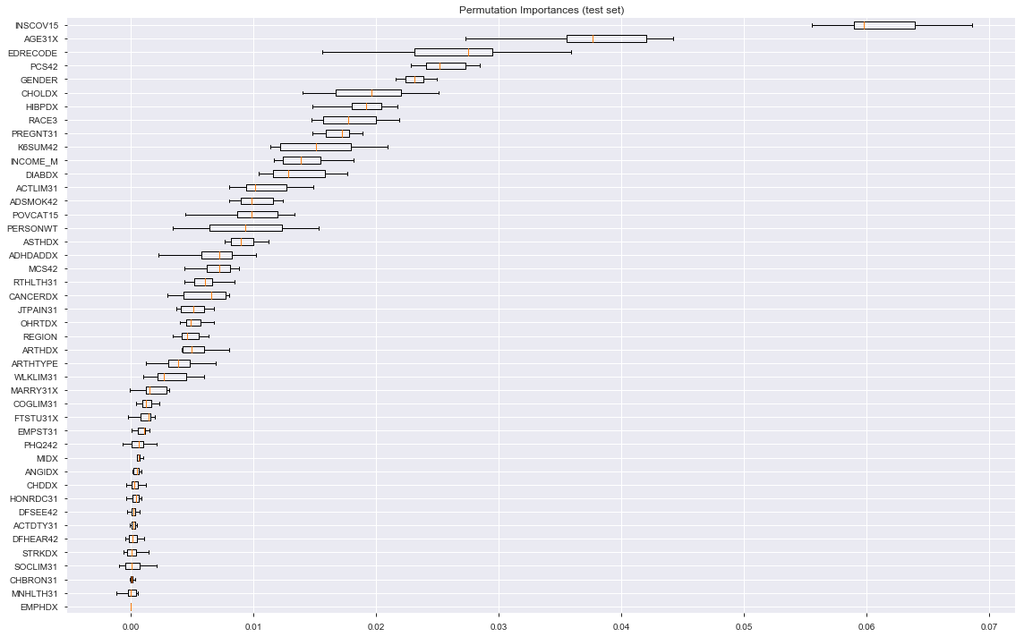

Model 2:

- zmienne kategoryczne - one-hot encoding
- zmienne ciągłe - standard scaler
- regressor - GBR
- zmienna uznana za istotną zmieniona na ciągłą - EDRECODE - poziom wykształcenia, wartosci (-1, 1, 2, 3, 13, 14, 15, 16) - im wyższe tym lepsze wykształcenie
- r2 = 0.377

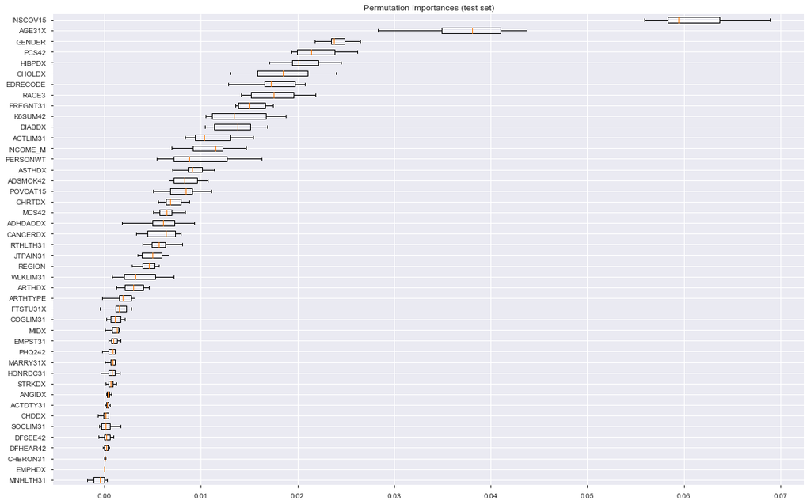

Komentarz:

Zmiana sposobu interpretacji zmiennej EDRECODE (z kategorycznej na ciągłą) spowodowała spadek ważności tej zmiennej. Z jednej strony można by to zinterpretować tak, że w formie ciągłej, ta zmienna jest słabszym predyktorem, a więc podjęte działanie było niewłaściwe. Z drugiej jednak strony wskaźnik r2 minimalnie wzrósł.

Model 3:

- zmienne kategoryczne - one-hot encoding
- zmienne ciągłe - minmaxscaler
- regressor - GBR
- wszystkie zmienne związane z diagnozą choroby (['HIBPDX', 'CHDDX', 'ANGIDX', 'MIDX', 'OHRTDX', 'STRKDX', 'EMPHDX', 'CHOLDX', 'CANCERDX', 'DIABDX', 'ARTHDX', 'ASTHDX', 'ADHDADDX']) zsumowane do jednej zmiennej 'ALL_DX'
- r2 = 0.378

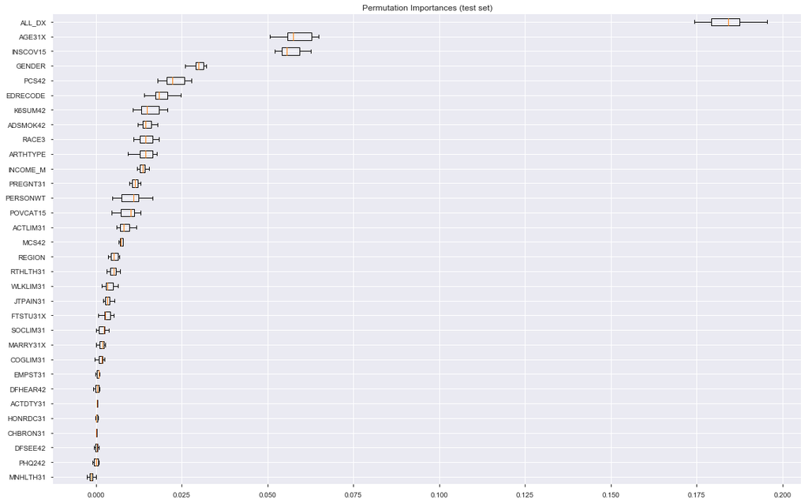

Komentarz:

Nowo wprowadzona zmienne okazała się być najbardziej istotną. Można wnioskować, że jest to swego rodzaju suma istotności zmiennych, z których ta zmienna została utworzona.

Model 4:

- zmienne kategoryczne - one-hot encoding
- zmienne ciągłe - minmaxscaler
- regressor - regresja liniowa
- wszystkie zmienne związane z diagnozą choroby (['HIBPDX', 'CHDDX', 'ANGIDX', 'MIDX', 'OHRTDX', 'STRKDX', 'EMPHDX', 'CHOLDX', 'CANCERDX', 'DIABDX', 'ARTHDX', 'ASTHDX', 'ADHDADDX']) zsumowane do jednej zmiennej 'ALL_DX'
- r2 = 0.338

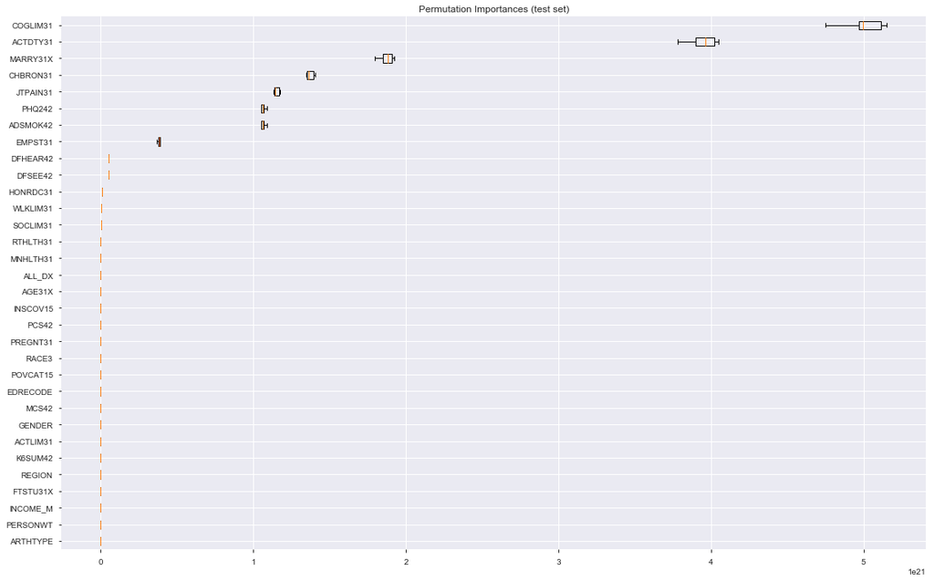

Komentarz:

W oczy rzuca się skala na osi X - wartości są znacznie większe od tych uzyskanych dla poprzednich modeli. Cecha, która poprzednio była najbardziej istotna ('ALL_DX') w tym modelu wydaje się nie mieć znaczenia. Za najważniejsze zostały uznane ograniczenia poznawcze ('COGLIM31') oraz stosunek do służby wojskowej (ACTDTY31). Co ciekawe ta zmienna kategoryczna przyjmuje 4 wartości - 1- aktywna służba, 2 - nie służy, 3 - nie dotyczy, mniej niż 16 lat, 4 - nie dotyczy, ponad 59 lat. Tak naprawdę więc, model mógł potraktować tę zmienną jako zmienną kategoryczną informującą o wieku badanego - stąd jej wysoka istotność.